# Coursera Reproducible Research course Week 2

## Part 1:Reading in the dataset

The data is loaded into R using ‘read.csv’. The dataset wasn’t edited after looking at it.

```r
##Set working directory and read the data into R
setwd("C:/Users/c268305/OneDrive - Eli Lilly and Company/coursera/reproducible data")
file <- read.csv("activity.csv", na.strings = "NA")
```

### Part 2: Total number of steps taken per day

1. Calculate the total number of steps

```r
##Total number of steps
y <- aggregate(file$steps, by = list(file$date), FUN = sum)
colnames(y) <- c("Date", "Total")
```

2a. Histogram of total number of steps

```r
##Histogram made from total number of steps
hist(y$Total, xlab = "Total number of steps", col = "blue", main = "Histogram of Total number of Steps", breaks = 25)
##Putting the figure into the
dir.create("Figures")
```

```
'Figures' already exists
```

```r
setwd("C:/Users/c268305/OneDrive - Eli Lilly and Company/coursera/reproducible data/Figures")
```

```
The working directory was changed to C:/Users/c268305/OneDrive - Eli Lilly and Company/coursera/reproducible data/Figures inside a notebook chunk. The working directory will be reset when the chunk is finished running. Use the knitr root.dir option in the setup chunk to change the working directory …
```

```r
dev.copy(png, file = "Total_steps.png")
```

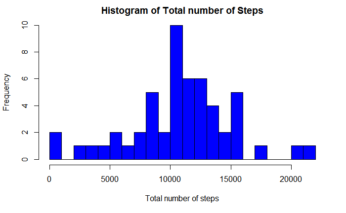

```r
dev.off()
```

3. The mean and median numebr of steps taken per day

```r
median <-median(y$Total, na.rm = T)
average <- mean(y$Total, na.rm = T)
median
```

```
[1] 10765
```

```r
average
```

```
[1] 10766.19
```

## Part 3: Average daily activity pattern

1. Make a time series plot (i.e. type=“l”) of the 5-minute interval (x-axis) and the average number of steps taken, averaged across all days (y-axis)

```r
file2 <- na.omit(file)
interval <- aggregate(file2$steps, by = list(file2$interval), FUN=mean)
colnames(interval) <- c("Interval", "Mean")
with(interval, {plot(Mean~Interval, type = "l", ylab = "Mean number of steps", main = "Average Daily Activity Pattern")})
##Putting the figure into the
setwd("C:/Users/c268305/OneDrive - Eli Lilly and Company/coursera/reproducible data/Figures")
```

```
The working directory was changed to C:/Users/c268305/OneDrive - Eli Lilly and Company/coursera/reproducible data/Figures inside a notebook chunk. The working directory will be reset when the chunk is finished running. Use the knitr root.dir option in the setup chunk to change the working directory …
```

```r
dev.copy(png, file = "Average_Daily_Activuty_Pattern.png")
```

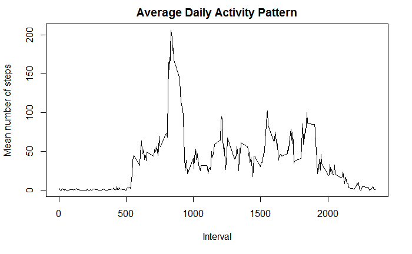

```r
dev.off()
```

2. Which 5-minute interval, on average across all the days in the dataset, contains the maximum number of steps? The answer is the interval 835

```r
which.max(interval$Mean)
```

```
[1] 104
```

```r
subset(interval, Mean == max(interval$Mean))
```

|  | Interval | Mean |
| --- | --- | --- |
| 104 | 835 | 206.1698 |

## Part 4: Replacing the missing values

1. Calculate and report the total number of missing values in the dataset (i.e. the total number of rows with NAs)

```r
NA_values <- is.na(file)
sum(NA_values)
```

```
[1] 2304
```

2. Devise a strategy for filling in all of the missing values in the dataset. The strategy does not need to be sophisticated. For example, you could use the mean/median for that day, or the mean for that 5-minute interval, etc.

```r
setwd("C:/Users/c268305/OneDrive - Eli Lilly and Company/coursera/reproducible data")
file <- read.csv("activity.csv", na.strings = "NA")
library(magrittr)
library(dplyr)
replacewithmean <- function(x) replace(x, is.na(x), mean(x, na.rm = TRUE))
changingtomean <- file%>% group_by(interval) %>% mutate(steps = replacewithmean(steps))
head(changingtomean)
```

| steps | date | interval |
| --- | --- | --- |
| 1.7169811 | 2012-10-01 | 0 |
| 0.3396226 | 2012-10-01 | 5 |
| 0.1320755 | 2012-10-01 | 10 |
| 0.1509434 | 2012-10-01 | 15 |
| 0.0754717 | 2012-10-01 | 20 |
| 2.0943396 | 2012-10-01 | 25 |

3. Create a new dataset that is equal to the original dataset but with the missing data filled in.

```r
dataset_2 <- as.data.frame(changingtomean)
```

4. Make a histogram of the total number of steps taken each day and Calculate and report the mean and median total number of steps taken per day.

```r
y <- aggregate(dataset_2$steps, by = list(dataset_2$date), FUN = sum)
colnames(y) <- c("Date", "Total")
##Histogram made from total number of steps
hist(y$Total, xlab = "Total number of steps", col = "blue", main = "Histogram of Total number of Steps", breaks = 25)
##Putting the figure into the
dir.create("Figures")
```

```
'Figures' already exists
```

```r
setwd("C:/Users/c268305/OneDrive - Eli Lilly and Company/coursera/reproducible data/Figures")
```

```
The working directory was changed to C:/Users/c268305/OneDrive - Eli Lilly and Company/coursera/reproducible data/Figures inside a notebook chunk. The working directory will be reset when the chunk is finished running. Use the knitr root.dir option in the setup chunk to change the working directory …
```

```r
dev.copy(png, file = "Edited_data_histogram.png")
```

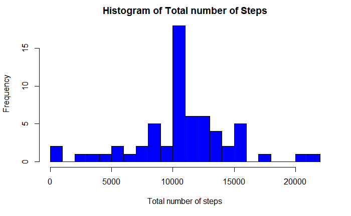

```r
dev.off()
```

Do these values differ from the estimates from the first part of the assignment? What is the impact of imputing missing data on the estimates of the total daily number of steps? By changing the NA values to the mean it has not changed the mean but it has changed the median so that it is the same as mean whereas it was lower when the NA’s were included.

```r
##Summary of mean and median of total number of steps
median <-median(y$Total, na.rm = T)
median
```

```
[1] 10766.19
```

```r
mean_of_data <- mean(y$Total, na.rm = T)
mean_of_data
```

```
[1] 10766.19
```

## Part 5: Are there differences in activity patterns between weekdays and weekends

1.Create a new factor variable in the dataset with two levels - “weekday” and “weekend” indicating whether a given date is a weekday or weekend day.

```r
dates <- as.Date(file$date, format="%Y-%m-%d")
date_time <- paste(as.Date(dates), file$date)
file$date <- as.POSIXct(date_time)
file$weekday <- ifelse(weekdays(file$date) == c("Saturday", "Sunday"), "weekend", "weekday")
file$Weekday <- weekdays(file$date)
```

2. Make a panel plot containing a time series plot (i.e. type=“l”) of the 5-minute interval (x-axis) and the average number of steps taken, averaged across all weekday days or weekend days (y-axis). See the README file in the GitHub repository to see an example of what this plot should look like using simulated data.

```r
##Finding the mean per day part per interval
file2 <- na.omit(file)
interval <- aggregate(file2$steps, by = list(file2$interval, file2$weekday), FUN=mean)
colnames(interval) <- c("Interval", "Day", "Mean")
##Second part of 5: Making a panel plot
library(ggplot2)
g <- ggplot(data = interval, aes(x = Interval, y = Mean, col = Day))
g + geom_line() + facet_grid(Day ~.)  + ylab("Mean number of steps") + ggtitle("Average Number of Steps in Weedays") + xlab("Interval")
##Putting the figure into the
setwd("C:/Users/c268305/OneDrive - Eli Lilly and Company/coursera/reproducible data/Figures")
```

```
The working directory was changed to C:/Users/c268305/OneDrive - Eli Lilly and Company/coursera/reproducible data/Figures inside a notebook chunk. The working directory will be reset when the chunk is finished running. Use the knitr root.dir option in the setup chunk to change the working directory …
```

```r
dev.copy(png, file = "WeekdaysvsWeekends.png")
```

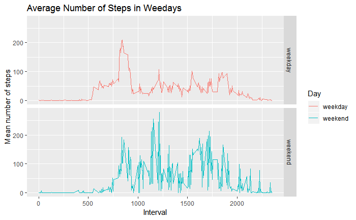

```r
dev.off()
```